# International Stroke Trial

The International Stroke Trial was a study comparing the effectiveness of medications in a populaton of patients who had suffered strokes  
( The publication was in the leading British medical journal Lancet: http://www.sciencedirect.com/science/article/pii/S0140673697040117)

### Preliminaries

- The definition of the primary outcome in this study:  
  Death or dependence at 6 months, also death within 14 days
- The variable name(s) for the intervention, and their possible values:  
  Aspirin (RXASP: (Y,N)) and Heparin (RXHEP: (M,L,N))
- The population being studied:  
  Patient have had a stroke within the last 48 hours, have no evidence of intracranial bleeding, and have no clear contraindications to the trial drugs
- Covariates included in this study: Demographics including age, gender, and clinical features at time of presentation

### Input files and load packages

```r
loadlib <- function(libs){
  for(lib in libs){
    if(!do.call(require,as.list(lib))) install.packages(lib)
    do.call(require,as.list(lib))
  }
}
libs = c("tidyverse","ggplot2","tableone","mice","randomForest")
loadlib(libs)

IST <- read_csv("IST_corrected.csv")
```

### Table one

Descriptive statistics for in groups of {aspirin, no aspirin} use, including information on age, gender, systolic blood pressure, and conscious state.  
Variable name: AGE,SEX,RXASP(aspirin),RSBP(blood pressure),RCONSC(conscious state)

```r
CreateTableOne(data = IST %>% select(SEX,AGE,RSBP,RCONSC,RXASP),strata = "RXASP")
```

```
##                   Stratified by RXASP
##                    N              Y               p      test
##   n                  9715           9720
##   SEX = M (%)        5254 (54.1)    5153 ( 53.0)   0.140
##   AGE (mean (sd))   71.70 (11.60)  71.73 (11.64)   0.830
##   RSBP (mean (sd)) 160.32 (27.52) 160.00 (27.70)   0.429
##   RCONSC (%)                                       1.000
##      D               2127 (21.9)    2127 ( 21.9)
##      F               7458 (76.8)    7463 ( 76.8)
##      U                130 ( 1.3)     130 (  1.3)
##   RXASP = Y (%)         0 ( 0.0)    9720 (100.0)  <0.001
```

### Machine Learning Analysis

# Assumptions:

1. Use a simple 50-50 train-test split
2. Outcome of interest: dead or dependent at 6 months
- Percent of patients are dead or dependent at 6 months in train set and test set:

```r
IST = IST %>%
  mutate(dod=ifelse(OCCODE==1|OCCODE==2,1,0))
set.seed(123)

random = sample(1:nrow(IST),nrow(IST)/2)
ist.train = IST[random,]
ist.test = IST[-random,]

ist.train %>% group_by(dod) %>% summarise(train = n()) %>%
  bind_cols(test = ist.test %>% group_by(dod) %>% summarise(test = n()) %>%    select(test)) %>% mutate(trainPct = round(train/nrow(ist.train),3), testPct = round(test/nrow(ist.test),3))
```

```
## # A tibble: 2 x 5
##     dod train  test trainPct testPct
##   <dbl> <int> <int>    <dbl>   <dbl>
## 1     0  3630  3680    0.374   0.379
## 2     1  6087  6038    0.626   0.621
```

- Choose variables to include in the model:

```r
variables = c("RDELAY","RCONSC","SEX","AGE","RSLEEP","RATRIAL","RCT",
              "RVISINF","RHEP24","RASP3","RSBP","RDEF1","RDEF2","RDEF3",
              "RDEF4","RDEF5","RDEF6","RDEF7","RDEF8","STYPE","RXASP","RXHEP","dod")

IST.var = IST[,variables]

# convert features that are integers but really categorical
IST.var[map(IST.var,function(x) length(unique(x))<10) %>% unlist()] = map(IST.var[,map(IST.var,function(x) length(unique(x))<10) %>% unlist()],as.factor)
```

- Handling Missing Data
  - outcome cannot be included in the imputation
  - decide whether to exclude, impute, and/or use indicator variables for data with missing values.

```r
IST.impute = IST.var
IST.impute[IST.impute=='C'|IST.impute=='c'] = NA

# check missing values in each variable
map(IST.impute,function(x) sum(is.na(x)))
```

```
## $RDELAY
## [1] 0
##
## $RCONSC
## [1] 0
##
## $SEX
## [1] 0
##
## $AGE
## [1] 0
##
## $RSLEEP
## [1] 0
##
## $RATRIAL
## [1] 984
##
## $RCT
## [1] 0
##
## $RVISINF
## [1] 0
##
## $RHEP24
## [1] 344
##
## $RASP3
## [1] 984
##
## $RSBP
## [1] 0
##
## $RDEF1
## [1] 247
##
## $RDEF2
## [1] 123
##
## $RDEF3
```

[output cut: 13 more lines]

```
##
## $RDEF8
## [1] 1249
##
## $STYPE
## [1] 0
##
## $RXASP
## [1] 0
##
## $RXHEP
## [1] 0
##
## $dod
## [1] 0
```

```r
# use MICE to impute missing value
mIST = mice(IST.impute %>% select(-dod), m=1, maxit=5)
IST.mice = mice::complete(mIST) %>% as_tibble()
IST.mice = data.frame(dod = IST.impute$dod) %>% bind_cols(IST.mice) %>% as_tibble()

IST.mice = IST.mice %>% mutate_if(is.character,as.factor)
random = sample(1:nrow(IST.mice),nrow(IST.mice)/2)
train_i = IST.mice[random,]
test_i = IST.mice[-random,]
```

- Logistic Regression

```r
lr = glm(dod~.,data=train_i,family=binomial(link='logit'))
lr_pred = predict(lr,test_i,type='response') %>% as_tibble() %>% mutate(truth = test_i$dod,pred = value >0.5)
```

- Random Forest

```r
rf = randomForest(dod~.,data=train_i %>% filter(!is.na(dod)))
rf_pred = predict(rf,test_i,type='prob')[,2] %>% as_tibble()
rf_pred = rf_pred %>% mutate(truth = test_i$dod, pred = value > 0.5)
```

- RF - variable importance

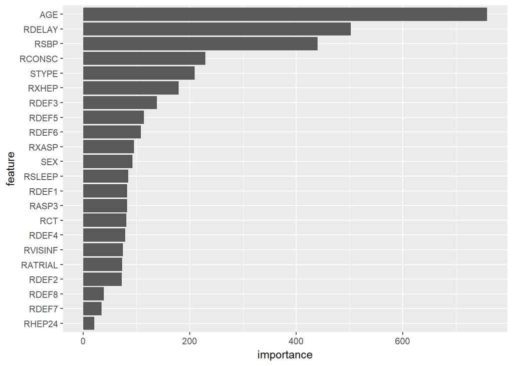

```r
# variable importance
rf_var = rf$importance %>% as.data.frame() %>% rownames_to_column()
rf_var = rf_var %>% rename(feature = rowname, importance = MeanDecreaseGini)
rf_var %>%
  mutate(feature = fct_reorder(feature,importance)) %>%
  ggplot(aes(x=feature,y=importance)) +
  geom_col()+
  coord_flip()
```

- Accuracy For Logistic Regression and Random Forest

```r
confidence_interval = function(accuracy, n, z=-qnorm(0.025)) {
  (z * sqrt(accuracy*(1-accuracy)/n)) %>%
    (function(se) c(accuracy-se, accuracy+se))
}

# lr accuracy
lr_accuracy = lr_pred %>% select(-value) %>% table() %>% (function(.) sum(diag(.)/sum(.)))
lr_ci = confidence_interval(lr_accuracy,n=nrow(lr_pred))

# rf accuracy
rf_accuracy = rf_pred %>% select(-value) %>% table() %>% (function(.) sum(diag(.)/sum(.)))
rf_ci = confidence_interval(rf_accuracy,n=nrow(rf_pred))

accuracy = data_frame(method = c('LR','RF'),
           accuracy = c(lr_accuracy,rf_accuracy),
           ci_upper = c(lr_ci[1],rf_ci[1]),
           ci_lower = c(lr_ci[2],rf_ci[2]))
```

[output not shown]

- ROC curve for LR and RF

```r
library(ROCR)
```

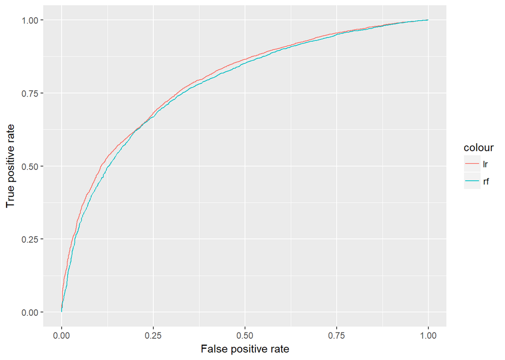

```r
lr_pred$pred <- as.numeric(lr_pred$pred)
rf_pred$pred <- as.numeric(rf_pred$pred)

# prediction:Function to create prediction objects:
# prediction(prediction,label)

# performance: function to create performance objects:
# performance(prediction.obj,measure)
method_performance = function(pred,truth,y="tpr",x="fpr"){
  prediction(pred,truth) %>% performance(y,x)
}

roc = list()
roc$lr = method_performance(lr_pred$value,lr_pred$truth)
roc$rf = method_performance(rf_pred$value,rf_pred$truth)


df_plot <- function(pref){
  df = data_frame(y=pref@y.values[[1]],
                  x=pref@x.values[[1]])
  df
}

roc_plot <- function(roc){
  ggplot(data = df_plot(roc$lr),aes(x=x,y=y,color='lr'))+
    geom_line()+
    geom_line(data=df_plot(roc$rf),aes(x=x,y=y,color='rf'))+
    xlab(roc$lr@x.name) + ylab(roc$lr@y.name)
}

roc_plot(roc)
```

### Conclusion

1. The average treatment effect of aspirin on death or dependence at 6 months: ATE = P(dod=1|RXASP=1) - P(dod=1|RXASP=0) = -0.013.  
   This was not the finding the trials team hoped to find. Aspirin marginally reduced death or dependence in this study, but was not significant.

```r
table(IST$RXASP,IST$dod)
```

```
##
##        0    1
##   N 3590 6125
##   Y 3720 6000
```

```r
# P(dod=1|RXASP=1)
p1 = 6000/(6000+3720)
# P(dod=1|RXASP=0)
p2 = 6125/(6125+3590)

p1-p2
```

```
## [1] -0.0131844
```

2. Number to treat: 1/|ATE| = 75

```r
1/abs(p1-p2)
```

```
## [1] 75.84723
```

```r
p1/p2
```

```
## [1] 0.9790879
```